# Tropical secondary forest regeneration conserves high levels of avian phylogenetic diversity - ScienceDirect

## Figures (3)

[figure not shown]

[figure not shown]

## Extras (1)

1. Supplementary material

## [Biological Conservation](https://www.sciencedirect.com/science/journal/00063207)

[Volume 209](https://www.sciencedirect.com/science/journal/00063207/209/supp/C), May 2017, Pages 432-439

# Tropical secondary forest regeneration conserves high levels of avian phylogenetic diversity

[David P.Edwards<sup>a</sup>](https://www.sciencedirect.com/science/article/pii/S0006320716310412#!)[Michael R.Massam<sup>a</sup>](https://www.sciencedirect.com/science/article/pii/S0006320716310412#!)[TorbjørnHaugaasen<sup>b</sup>](https://www.sciencedirect.com/science/article/pii/S0006320716310412#!)[James J.Gilroy<sup>b</sup><sup>c</sup>](https://www.sciencedirect.com/science/article/pii/S0006320716310412#!)

https://doi.org/10.1016/j.biocon.2017.03.006[Get rights and content](https://s100.copyright.com/AppDispatchServlet?publisherName=ELS&contentID=S0006320716310412&orderBeanReset=true)

Under a Creative Commons [license](https://creativecommons.org/licenses/by/4.0/)

open access

## Abstract

[Secondary forests](https://www.sciencedirect.com/topics/agricultural-and-biological-sciences/secondary-forests) are promoted as having pivotal roles in reversing the tropical extinction crisis. While secondary forests recover carbon and species over time, a key question is whether [phylogenetic](https://www.sciencedirect.com/topics/agricultural-and-biological-sciences/cladistics) diversity—the total evolutionary history across all species within a community—also recovers. Conserving phylogenetic diversity protects unique phenotypic and ecological traits, and benefits ecosystem functioning and stability. We examined the extent to which avian phylogenetic diversity recovers in secondary forests in the Colombian Chocó-Andes. sesPD, a measure of phylogenetic richness corrected for [species richness](https://www.sciencedirect.com/topics/earth-and-planetary-sciences/species-richness), recovered to [old-growth forest](https://www.sciencedirect.com/topics/earth-and-planetary-sciences/old-growth-forest) levels after ~ 30 years, while sesMPD, a measure of the phylogenetic distance between individuals in a community, recovered to old-growth levels even within young secondary forest. Mean evolutionary distinctiveness also recovered rapidly in secondary forest communities. Our results suggest that secondary forests can play a vital role in conserving distinct evolutionary lineages and high levels of evolutionary history. Focusing conservation and carbon-based payments for ecosystem services on secondary forest recovery and their subsequent protection thus represent a good use of scarce conservation resources.

## Keywords

Carbon enhancements

Cloud forest

Forest restoration

Natural regeneration

REDD +

Secondary forest

Tropical Andes

## 1. Introduction

More than 150,000,000 ha of tropical forest were converted for farming between 1980 and 2012 (Gibbs et al., 2010, Hansen et al., 2013). The conversion of tropical forest to farmland is the major driver of the global extinction crisis (Laurance et al., 2014), causing dramatic species loss (Gibson et al., 2011) as forest specialists are replaced by widespread habitat [generalists](https://www.sciencedirect.com/topics/earth-and-planetary-sciences/generalist) (Socolar et al., 2016). There is also a reduction in the diversity of ecological functions (e.g., pollination or nutrient cycling) fulfilled by communities (Edwards et al., 2013, Edwards et al., 2014b, Flynn et al., 2009) and a loss of the [phylogenetic](https://www.sciencedirect.com/topics/agricultural-and-biological-sciences/cladistics) diversity (or total evolutionary history) within communities (Edwards et al., 2015, Frishkoff et al., 2014, Prescott et al., 2016) when forest is converted to farmland.

Given that the loss of primary tropical forests is likely to continue, particularly in productive tropical ecosystems, there is increasing interest in the potential for [secondary forests](https://www.sciencedirect.com/topics/agricultural-and-biological-sciences/secondary-forests) that regenerate naturally on abandoned farmland to mitigate some of the forest and biodiversity losses (Chazdon, 2014). This is particularly so in more marginal agricultural areas—such as those that are too dry or steep for modern agriculture—where conservation gains could be made at minimal financial cost to conservation funds or to carbon-based payments for ecosystem service schemes (e.g., carbon enhancements under REDD +) (Gilroy et al., 2014b). In some regions that have already undergone substantial loss of [primary forest](https://www.sciencedirect.com/topics/agricultural-and-biological-sciences/primary-forests), including Central America, the Tropical Andes, and the Philippines, there is already a phase of farm abandonment, equating to > 360,000 km<sup>2</sup> of new woody vegetation in Latin America and the Caribbean between 2001 and 2010 (Aide et al., 2013).

Over time, there are major benefits of secondary forest recovery in terms of [carbon sequestration](https://www.sciencedirect.com/topics/earth-and-planetary-sciences/carbon-sequestration) and [carbon stocks](https://www.sciencedirect.com/topics/agricultural-and-biological-sciences/carbon-sink) (Chazdon, 2008). The rate of carbon absorption in 20-year secondary forests of the [lowland](https://www.sciencedirect.com/topics/agricultural-and-biological-sciences/lowlands) [Neotropics](https://www.sciencedirect.com/topics/earth-and-planetary-sciences/neotropics) is 11-fold the rate in [old-growth forests](https://www.sciencedirect.com/topics/earth-and-planetary-sciences/old-growth-forest) and above-ground biomass stocks take a median of 66 years to recover 90% of old-growth above-ground biomass levels (Poorter et al., 2016). In the Tropical Andes (> 1000 m a.s.l.), approximately half of old-growth above-ground biomass was restored in ~ 30 years (Gilroy et al., 2014b). In turn, there is a significant recovery of biodiversity within secondary forests (Barlow et al., 2007, Gilroy et al., 2014b, Queiroz et al., 2014), including a host of threatened forest-dwelling species (Basham et al., 2016, Gilroy et al., 2014b).

A key knowledge gap in determining whether secondary forest regrowth can play a significant role in reversing biodiversity losses is whether phylogenetic diversity also recovers over time. Phylogenetic diversity—the total evolutionary history and the way in which evolutionary relationships are patterned in a site or community (Faith, 1992)—provides insights into patterns of community assembly (Webb et al., 2002, Pavoine and Bonsall, 2011) and has intrinsic conservation value (Winter et al., 2013). Focusing on the conservation of phylogenetic diversity means that a greater proportion of evolutionary history is preserved, decreasing the chance of unique phenotypic and ecological traits being lost forever (Jetz et al., 2014).

In this study, we use field data from the Chocó-Andes of Colombia, a zone straddling two of the most highly threatened hotspots of global biodiversity (Myers et al., 2000), to examine the extent to which phylogenetic diversity recovers in secondary forests. We use birds as model communities, because they have a preliminary global phylogeny (derived from genetic data for 6663 species, and thus lacking genetic data for approximately a third of known species; Jetz et al., 2012), are functionally important (Sekercioglu, 2006), cost-effective to sample rigorously (Gardner et al., 2008) and are a good predictor of the impacts of [land-use change](https://www.sciencedirect.com/topics/earth-and-planetary-sciences/land-use-change) on other taxa (Barlow et al., 2007, Edwards et al., 2014a). We do so by quantifying bird community dynamics across sample sites in farmland, secondary forest of different ages, and primary forest, to predict whether phylogenetic diversity can recover to primary forest levels.

## 2. Materials and methods

### 2.1. Study areas

We sampled bird communities at points arrayed within 400 m × 400 m squares located randomly across the landscape in proportion to habitat cover: 20 squares in pasture, 9 in young secondary forest (< 15 year), 6 in well-established secondary forest (> 15 year), and 23 in primary forest (Fig. A1; also see (Gilroy et al., 2014b) for further details). Squares were spaced ≥ 300 m apart between habitats and ≥ 400 m within habitats. All young secondary forests were owned by conservation [NGOs](https://www.sciencedirect.com/topics/earth-and-planetary-sciences/non-governmental-organisation), who provided detailed records of stand ages. Ages of older secondary forests (15–35 years) were estimated through informal interviews with locals and reserve managers, taking the mean when reported ages differed. Beyond the exclusion of cattle, all secondary forests were unmanaged, and all had some degree of connectivity to primary forest, which is typical of the majority of secondary regeneration in the tropics (Crk et al., 2009, Endress and Chinea, 2001, Helmer, 2000, Sloan et al., 2016).

### 2.2. Bird surveys

Bird sampling used repeat-visit point counts at three sampling points within each square (174 points in total; (Gilroy et al., 2014a)), with 200 m spacing between points to allow community independence (Hill and Hamer, 2004). We visited each point on four consecutive mornings for counts of 10-minute duration (06:00 to 12:00), avoiding conditions of rain or high winds. We varied the routes taken by observers each day to ensure that each point was visited both early and late in the sampling window. We recorded unknown [vocalizations](https://www.sciencedirect.com/topics/earth-and-planetary-sciences/vocalization) using Sennheiser ME66 microphones and Olympus LS11 recording devices, allowing subsequent identification using online reference material ([www.xeno-canto.org](http://www.xeno-canto.org/), recordings deposited in the Colección de Sonidos Ambientales, Instituto Alexander von Humboldt, Colombia). We restricted our analyses to detections within an estimated 100 m radius, excluding records of highly mobile or transient species (e.g. non-breeding trans-continental migrants, large [raptors](https://www.sciencedirect.com/topics/earth-and-planetary-sciences/raptor), and swifts). All point counts were conducted by experienced observers familiar with the regional avifauna (JJG and DPE) from January to March and June to July 2012, corresponding with the relatively dry period in the region.

### 2.3. Measures of phylogenetic diversity

We calculated six abundance-weighted measures of [phylogenetic](https://www.sciencedirect.com/topics/agricultural-and-biological-sciences/cladistics) diversity and two measures of evolutionary uniqueness for each sampling point. For each metric, we used 500 trees downloaded from http://birdtree.org/ (Jetz et al., 2012) based on the Hackett backbone (used to constrain deep-level relationships among major clades; (Hackett et al., 2008)). Having checked that the 500 values were normally distributed for each metric, we took the mean value (see below) at each sample point to ensure that our results were robust to phylogenetic uncertainty.

*PD* (phylogenetic diversity) – the sum of evolutionary history in a community (Faith, 1992), given in millions of years.

*sesPD* (the standard effect size (ses) of PD) – PD is positively related with [species richness](https://www.sciencedirect.com/topics/earth-and-planetary-sciences/species-richness) (Swenson, 2014). Thus, sesPD was calculated by comparing observed PD with that of null communities of equal species richness drawn randomly from the regional species pool (Swenson, 2014). Positive values of sesPD indicate higher PD than expected by chance for a given species richness, while negative values indicate lower PD than expected by chance.

MPD (mean pairwise distance) – the average phylogenetic distance between all combinations of pairs of individuals (including conspecifics) in a community.

*sesMPD* (the standard effect size (ses) of MPD) – mean phylogenetic distance between all combinations of pairs of individuals, corrected for species richness (as MPD can be positively correlated with richness). Higher values indicate that communities contain species that are distributed across clades that diverged from each other a long time ago (more phylogenetically even), whereas lower values indicate communities consisting of species that are distributed within clades with relatively recent [common ancestors](https://www.sciencedirect.com/topics/earth-and-planetary-sciences/common-ancestry) (more phylogenetically clustered) (Webb et al., 2002).

MNTD (mean nearest taxon distance) – the average distance between an individual and the most closely related (non-conspecific) individual. MNTD is thus affected by phylogenetic distance in terminal branches.

*sesMNTD* (the standard effect size (ses) of MNTD) – mean nearest taxon distance corrected for species richness, as MNTD and richness may be positively correlated. Communities with greater MNTD than expected for a given species richness have positive values, suggesting that closely related individuals do not co-occur in the community (more phylogenetically even), and those with lower MNTD than expected have negative values suggesting the co-occurrence of closely related individuals (more phylogenetically clustered).

*ED* (evolutionary distinctiveness) – a measure of how much unique evolutionary history a species contributes to a phylogenetic tree. Species with no extant close relatives have high values of ED, whereas species with closely related extant species have low values. A community with high ED thus has more evolutionarily unique species.

*EDR* (evolutionary distinctiveness rarity) – ED adjusted for species rarity measured by range size. Species with highest EDR thus implies both high importance for the conservation of evolutionary diversity and an elevated risk of extinction associated with a small global range size.

We calculated these six metrics of phylogenetic diversity using the picante package (Kembel et al., 2010) in R version 3.3.1 (R Core Team 2016). To calculate standard effect sizes (ses), we used null models with an independent swap algorithm that constrains species richness at each point but randomly draws species from the regional species pool to generate 999 null communities against which to compare the observed community (Edwards et al., 2015, Frishkoff et al., 2014). We did this for each metric (PD, MPD and MNTD), and for all 500 trees. Metrics were abundance-weighted using the highest count of a species during a single visit to each point (i.e. across the four point count repeats). We obtained a single measure of ED for each species from a global phylogeny of birds (Jetz et al., 2014), revealing the distinctiveness of each species at a global level rather than within our samples. We then calculated the mean ED of the species recorded at each sample point in our study. Finally, we calculated mean EDR for each species by dividing the mean ED by its global range size (km<sup>2</sup>) using values taken from (Jetz et al., 2014), and again calculating the mean EDR of the species recorded at each sample point.

### 2.4. Statistical analysis

We analysed the effect of habitat (pasture, secondary forest, and old-growth forest) on each of the phylogenetic diversity and evolutionary distinctiveness metrics using linear mixed-effects models to account for potential spatial autocorrelation between points in the same transect and/or site. For secondary forest points, we also analysed whether there was an effect of years since abandonment on each metric. All models included altitude as a fixed effect and sampling site as a random effect, and were fitted using maximum likelihood in the lme4 R package (Bates et al., 2014). We checked model residuals for normality and homoscedasticity. We compared model likelihood relative to null models (including only intercept and altitude terms, plus site random effects) using AIC (Anderson, 2008). We used Nagakawa and Schielzeth's R<sup>2</sup> (Nakagawa and Schielzeth, 2013), calculated using the MuMIn R package (Barton, 2014) to determine how much of the data were explained by fixed and random effects in each of the linear mixed-effects models. We estimated the significance of pairwise differences between habitat effects using Tukey post-hoc tests in the multcomp R package (Hothorn et al., 2008), and estimated the significance of secondary forest age effects using likelihood ratio tests. To ensure that our results were not affected by spatial autocorrelation, we performed Moran's I test, implemented using the ape package in R (Paradis et al., 2004).

## 3. Results

### 3.1. Phylogenetic diversity

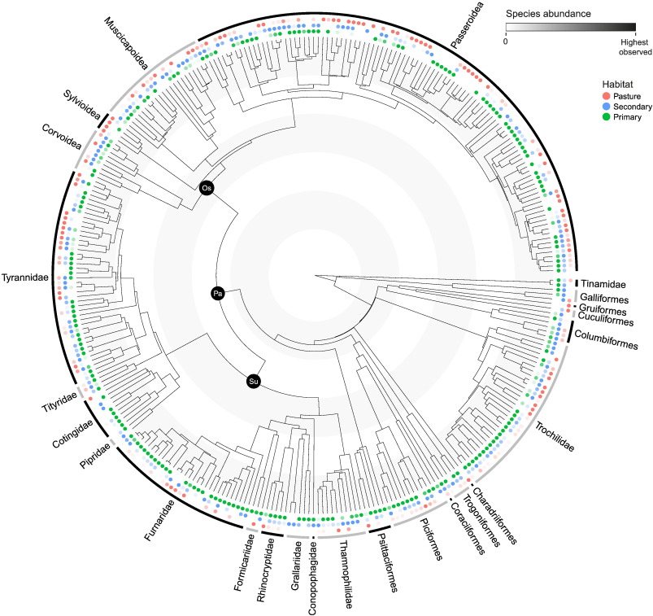

1. [Download : Download high-res image (1MB)](https://ars.els-cdn.com/content/image/1-s2.0-S0006320716310412-gr1_lrg.jpg)
2. [Download : Download full-size image](https://ars.els-cdn.com/content/image/1-s2.0-S0006320716310412-gr1.jpg)

Fig. 1. [Phylogenetic](https://www.sciencedirect.com/topics/agricultural-and-biological-sciences/cladistics) distribution of Chocó-Andean birds in pasture and in [secondary and primary forest](https://www.sciencedirect.com/topics/agricultural-and-biological-sciences/secondary-forests). Spots show a species presence in a particular habitat, with the darkness of spot colour indicating a species' abundance (scale bar: ‘highest observed’ represents the highest maximum abundance recorded of a species on any point count). Major nodes indicate [passerines](https://www.sciencedirect.com/topics/agricultural-and-biological-sciences/passeriformes) (Pa), suboscines (Su), and oscines (Os).

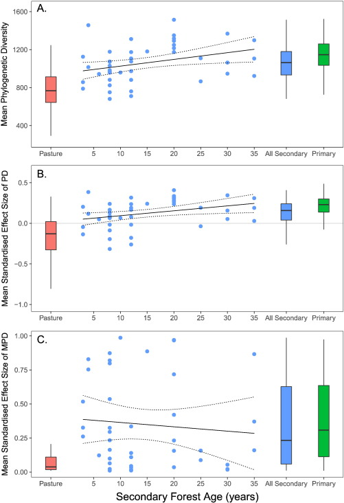

1. [Download : Download high-res image (449KB)](https://ars.els-cdn.com/content/image/1-s2.0-S0006320716310412-gr2_lrg.jpg)
2. [Download : Download full-size image](https://ars.els-cdn.com/content/image/1-s2.0-S0006320716310412-gr2.jpg)

Fig. 2. Indices of [phylogenetic](https://www.sciencedirect.com/topics/agricultural-and-biological-sciences/cladistics) diversity across habitat types (box whisker plots), with a regression against [secondary forest](https://www.sciencedirect.com/topics/agricultural-and-biological-sciences/secondary-forests) age: A) Mean phylogenetic diversity, PD; B) mean standard effect size of phylogenetic diversity, sesPD; and C) mean standard effect size of mean pairwise distance, sesMPD. Box whisker plots show median, interquartile and 1.5 × interquartile ranges; dotted lines represent 95% confidence intervals.

The standardized pairwise phylogenetic distance between species (sesMPD) was higher in secondary forest than pasture (t ratio = − 4.539, *P* < 0.001), and again, secondary forest did not differ with old-growth (t ratio = 0.111, *P* = 0.992) (Fig. 2C). There was, however, no impact of forest age (Table C2): even after a few years of recovery, sesMPD levels were similar to old-growth (Fig. 2C). Non-standardised MPD showed similar patterns to sesMPD (Fig. C1A; Tables C1 & C2). There was no significant effect of habitat or of secondary forest age on sesMNTD (Fig. C1C). Non-standardised MNTD showed similar patterns, except for significantly higher MNTD in secondary forest than in [primary forest](https://www.sciencedirect.com/topics/agricultural-and-biological-sciences/primary-forests) (Fig. C1B; Tables C1 & C2), likely an effect of relatively high [species richness](https://www.sciencedirect.com/topics/earth-and-planetary-sciences/species-richness) in secondary forest (Gilroy et al., 2014b). We did not detect spatial autocorrelation for any of the model residuals (*P* > 0.05 for all Moran's I tests).

### 3.2. Evolutionary distinctiveness

Species abundance in pasture was weakly negatively correlated with both ED (Fig. C2a; slope = − 9.417, *P* = 0.001) and EDR (Fig. C2b; slope = − 0.289, *P* = 0.049), whereas neither metric was significantly correlated with abundance in secondary or old-growth forests (Fig. C2c-f). Correspondingly, including habitat as a fixed effect improved model fit (Table C1), and mean ED and EDR showed substantial recoveries in secondary forest communities versus pasture (Fig. 3; ED, t ratio = − 6.491, *P* < 0.001; EDR, t ratio = − 4.234, *P* < 0.001). In comparison with old-growth, secondary forest had similar levels of mean ED (Fig. 3A, t ratio = 2.046, *P* = 0.106) and slightly lower levels of mean EDR (Fig. 3B, t ratio = 3.661, *P* = 0.002). Including secondary forest age also improved model fit (Table C2), with a positive impact of secondary forest age on mean ED (likelihood ratio test, *P* < 0.0001), reaching old-growth levels at ~ 25 years since abandonment (Fig. 3A). However, there was no impact of age on EDR (likelihood ratio test, *P* = 0.451), suggesting that EDR recovers very rapidly after abandonment, but does not seem to recover further towards old-growth levels over 35 years (Fig. 3B). Again, we did not detect spatial autocorrelation for any of the model residuals (*P* > 0.05 for all Moran's I tests).

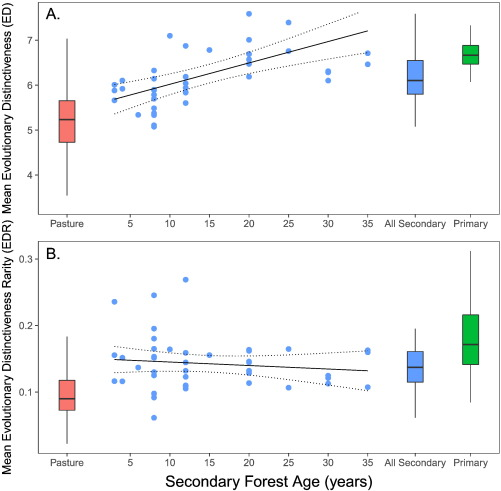

1. [Download : Download high-res image (285KB)](https://ars.els-cdn.com/content/image/1-s2.0-S0006320716310412-gr3_lrg.jpg)
2. [Download : Download full-size image](https://ars.els-cdn.com/content/image/1-s2.0-S0006320716310412-gr3.jpg)

Fig. 3. A) Mean evolutionary distinctiveness and B) mean evolutionary distinctiveness rarity across habitat types (box whisker plots), with a regression against [secondary forest](https://www.sciencedirect.com/topics/agricultural-and-biological-sciences/secondary-forests) age. Box whisker plots show median, interquartile and 1.5 × interquartile ranges; dotted lines represent 95% confidence intervals.

## 4. Discussion

Understanding whether [secondary forest](https://www.sciencedirect.com/topics/agricultural-and-biological-sciences/secondary-forests) regrowth on abandoned agricultural lands recovers [phylogenetic](https://www.sciencedirect.com/topics/agricultural-and-biological-sciences/cladistics) diversity is a key question, as this diversity is an important component of conservation value. Our models predict a recovery of phylogenetic diversity, phylogenetic distance (sesMPD & MPD), and evolutionarily distinctive species towards [primary forest](https://www.sciencedirect.com/topics/agricultural-and-biological-sciences/primary-forests) levels within 30 years of secondary regeneration. This suggests that in tropical landscapes, investing in the recovery of secondary forest offers substantial benefits for the conservation of evolutionarily distinct biodiversity.

Our results show marked differences between forest and low-intensity agriculture for most diversity metrics, supporting findings that agricultural conversion of tropical forests threatens evolutionarily distinct species in particular, and indicating higher [extinction risk](https://www.sciencedirect.com/topics/earth-and-planetary-sciences/extinction-risk) among birds from basal lineages (Edwards et al., 2015, Frishkoff et al., 2014, Gaston and Blackburn, 1997). Agricultural conversion reduces phylogenetic diversity and increases phylogenetic clustering (Edwards et al., 2015, Frishkoff et al., 2014), underscoring the notion that preventing the loss of tropical forest for agriculture remains of upmost conservation importance (Laurance et al., 2014).

Two processes can explain the recovery of phylogenetic diversity in secondary forest: species gain and decreasing relatedness of species (Frishkoff et al., 2014). Our work has previously shown that [species richness](https://www.sciencedirect.com/topics/earth-and-planetary-sciences/species-richness) increases with secondary forest age (Gilroy et al., 2014b). However, after using null model approaches to account for species richness, our results still showed a recovery in phylogenetic diversity (sesPD) and sesMPD towards primary forest levels (Fig. 2B). Additionally, mean evolutionary distinctiveness increased over time to old-growth levels within secondary forest, while mean evolutionary distinctiveness rarity increased rapidly in early successional forest versus pasture. This supports the suggestion that younger lineages are more likely to exploit farmland, but that older lineages are able to repopulate forest as it recovers (Frishkoff et al., 2014).

We only studied a single tropical region and one taxonomic group. That said, birds are considered to be good indicators of wider biodiversity responses to environmental change (Barlow et al., 2007, Edwards et al., 2014a), representing a broad range of dispersal abilities. We accounted for phylogenetic uncertainty by averaging across 500 trees from http://birdtree.org/ (Jetz et al., 2012), using the Hackett backbone phylogeny for relationships between major clades (Hackett et al., 2008). Recent studies have proposed different theories for the deep evolutionary relationships between the major avian clades (Jarvis et al., 2014, Prum et al., 2015), revising the non-passerine relationships and suggesting a younger age of [passerines](https://www.sciencedirect.com/topics/agricultural-and-biological-sciences/passeriformes). The results of our study could plausibly be sensitive to the backbone chosen, if there are differences in the representation of major clades across habitats. However, given the preponderance of passerines (250 of 319 species) in this study, and the fact that backbones differ largely in their treatment of non-passerine clades, we suspect that using alternative theories for deep evolutionary relationships would not greatly affect our results. Nevertheless, further exploration of deep-clade variation and its impact on site-level phylogenetic diversity may be warranted.

Our samples come from secondary regrowth that is adjacent to contiguous primary forests; these forests are likely to act as sources of dispersing colonists within second growth (Gilroy and Edwards, 2017). The spatial configuration of [forest habitats](https://www.sciencedirect.com/topics/agricultural-and-biological-sciences/forest-habitats) within the wider landscape is likely to be an important determinant of dispersal rates (Gilroy et al., 2014a, Gilroy and Edwards, 2017), and therefore recovery patterns in second growth. Nevertheless, across the tropics the majority of secondary regeneration occurs adjacent to dominant remnant forests (Crk et al., 2009, Endress and Chinea, 2001, Helmer, 2000, Sloan et al., 2016), suggesting that our focus on secondary regrowth that is adjacent to contiguous primary forest yields broadly applicable results.

In the absence of data on habitat-specific demographic rates, we cannot assess whether secondary forest populations within our study sites are continually buffered by immigration from nearby primary forest, or are self-sustaining (Gilroy and Edwards, 2017). We are therefore unable to predict whether phylogenetic diversity will be maintained in secondary forest regrowth in those landscapes where undisturbed forests have been completely removed. Isolation of second growth from primary forest could result in a diminished pool of potential colonists, perhaps with fewer evolutionarily distinct species. Nevertheless, our results show that natural [forest regeneration](https://www.sciencedirect.com/topics/agricultural-and-biological-sciences/forest-regeneration) in cattle pastures surrounding extant primary forests could significantly enhance the protection of Andean phylogenetic diversity. Forest regeneration will thus directly boost population sizes of many evolutionarily distinctive species, while such species that are restricted to primary forest should benefit from enhanced dispersal potential between remaining primary forests (Turner and Corlett, 1996).

### 4.1. Management implications

Our results underline the vital role that the abandonment of existing pasturelands and resulting secondary forest regrowth represents for the recovery and conservation of distinct evolutionary lineages and high levels of total evolutionary history. Such forests can act as reservoirs for critical levels of phylogenetic diversity in regions that have lost the majority of forest, with important benefits particularly when targeted to buffer and connect existing [forest reserves](https://www.sciencedirect.com/topics/agricultural-and-biological-sciences/forest-reserves) (Frishkoff et al., 2014), facilitating the dispersal of evolutionarily distinctive species along corridors between isolated habitat tracts (Giam et al., 2015, Tscharntke et al., 2012).

Because of the low profitability of pasturelands in the Tropical Andes and elsewhere, there are opportunities for carbon-based payments for ecosystem services (PES; e.g., carbon enhancements under REDD +) to cheaply offer economic alternatives that promote growing forest carbon not cows (~$2 t<sup>− 1</sup> CO<sub>2</sub> in the Tropical Andes; Gilroy et al., 2014b). Zones with highest potential for recovery of phylogenetic diversity (i.e., agricultural areas close to contiguous forest; Gilroy et al., 2014a, Edwards et al., 2015) are perhaps also likely to be most economically favourable for carbon-based PES. First, the profitability of agriculture tends to decrease with distance from population centres (Raboin and Posner, 2012). Second, carbon accumulation is likely to be higher in naturally regenerating forests with some degree of connectivity to primary forest; secondary forests without this connectivity may not achieve such high rates of carbon accumulation without costly active management measures such as planting (Chazdon, 2008).

Carbon-based PES could be particularly important in providing poor rural land-owners with the leverage, both financial and legal, to cease uneconomical and environmentally damaging farming in marginal areas (Gilroy et al., 2014b), especially given that in the absence of strong economic returns cattle are often used as financial collateral and to bolster land claims (Dávalos et al., 2014). In post-conflict Colombia, people displaced by the armed conflict could return to abandoned farmland and seek to convert secondary forests to pastures (Sánchez-Cuervo and Aide, 2013), again highlighting the importance of providing alternative economic opportunities that retain secondary forests, including carbon-based PES. In conclusion, therefore, focusing conservation and carbon-based PES on secondary forest recovery and subsequent protection represent a good use of scarce conservation resources.

## Acknowledgements

We thank staff at the Instituto de Investigación de Recursos Biológicos Alexander von Humboldt, particularly C. Medina and F. Forero for logistical support, Fundación Colibri (Reserva Mesenia-Paramillo), Fundación ProAves (Reserva Las Tangaras) and L. Tapasco (Cerro Montezuma) for access permissions, and Y. Tapasco, O. Cortes, F. Prada, G. Suarez and many local assistants for help with data collection. Funding was provided to T.H. and D.P.E. by the Research Council of Norway, grant number 208836. M.A.M. was supported by a Natural Environment Research Council PhD studentship under the Adapting to the Challenges of a Changing Environment (ACCE) doctoral training partnership. This is publication #12 of the Biodiversity, Agriculture and Conservation in Colombia/Biodiversidad, Agricultura, y Conservación en Colombia (BACC) project.

## Appendix A. Supplementary data

[Download : Download Word document (4MB)](https://ars.els-cdn.com/content/image/1-s2.0-S0006320716310412-mmc1.docx)

Supplementary material

## References

**Aide et al., 2013**

T.M. Aide, M.L. Clark, H. Ricardo Grau, D. Lopez-Carr, M.A. Levy, D. Redo, M. Bonilla-Moheno, G. Riner, M.J. Andrade-Nunez, M. Muniz

**Deforestation and reforestation of Latin America and the Caribbean (2001–2010)**

Biotropica, 45 (2013), pp. 262-271

[CrossRef](https://doi.org/10.1111/j.1744-7429.2012.00908.x)[View Record in Scopus](https://www.scopus.com/inward/record.url?eid=2-s2.0-84874484363&partnerID=10&rel=R3.0.0)[Google Scholar](https://scholar.google.com/scholar?q=Deforestation%20and%20reforestation%20of%20Latin%20America%20and%20the%20Caribbean)

**Anderson, 2008**

D.R. Anderson

**Model Based Inference in the Life Sciences: A Primer on Evidence**

Springer, New York, New York, USA (2008)

[Google Scholar](https://scholar.google.com/scholar_lookup?title=Model%20Based%20Inference%20in%20the%20Life%20Sciences%3A%20A%20Primer%20on%20Evidence&publication_year=2008&author=D.R.%20Anderson)

**Barlow et al., 2007**

J. Barlow, T.A. Gardner, I.S. Araujo, T.C. Avila-Pires, A.B. Bonaldo, J.E. Costa, M.C. Esposito, L.V. Ferreira, J. Hawes, M.M. Hernandez, M.S. Hoogmoed, R.N. Leite, N.F. Lo-Man-Hung, J.R. Malcolm, M.B. Martins, L.A.M. Mestre, R. Miranda-Santos, A.L. Nunes-Gutjahr, W.L. Overal, L. Parry, S.L. Peters, M.A. Ribeiro-Junior, M.N.F. da Silva, C.D. Motta, C.A. Peres

**Quantifying the biodiversity value of tropical primary, secondary, and plantation forests**

Proc. Natl. Acad. Sci. U. S. A., 104 (2007), pp. 18555-18560

[CrossRef](https://doi.org/10.1073/pnas.0703333104)[View Record in Scopus](https://www.scopus.com/inward/record.url?eid=2-s2.0-36749043794&partnerID=10&rel=R3.0.0)Google Scholar

**Barton, 2014**

K. Barton

**MuMIn: Multi-Model Inference. R Package**

(2014)

[Google Scholar](https://scholar.google.com/scholar_lookup?title=MuMIn%3A%20Multi-Model%20Inference.%20R%20Package&publication_year=2014&author=K.%20Barton)

**Basham et al., 2016**

E.W. Basham, P. Gonzalez del Pliego, A.R. Acosta-Galvis, P. Woodcock, C.A. Medina Uribe, T. Haugaasen, J.J. Gilroy, D.P. Edwards

**Quantifying carbon and amphibian co-benefits from secondary forest regeneration in the Tropical Andes**

Anim. Conserv. (2016), 10.1111/acv.12276

Google Scholar

**Bates et al., 2014**

D. Bates, M. Maechler, B. Bolker, S. Walker

**lme4: Linear Mixed-Effects Models Using Eigen and S4. R Package Version 1**

(2014), pp. 0-6

[View Record in Scopus](https://www.scopus.com/inward/record.url?eid=2-s2.0-85015471382&partnerID=10&rel=R3.0.0)Google Scholar

**Chazdon, 2008**

R.L. Chazdon

**Beyond deforestation: Restoring forests and ecosystem services on degraded lands**

Science, 320 (2008), pp. 1458-1460

[CrossRef](https://doi.org/10.1126/science.1155365)[View Record in Scopus](https://www.scopus.com/inward/record.url?eid=2-s2.0-45849103567&partnerID=10&rel=R3.0.0)[Google Scholar](https://scholar.google.com/scholar_lookup?title=Beyond%20deforestation%3A%20Restoring%20forests%20and%20ecosystem%20services%20on%20degraded%20lands&publication_year=2008&author=R.L.%20Chazdon)

**Chazdon, 2014**

R.L. Chazdon

**Second Growth**

Chicago University Press, Chicago (2014)

[Google Scholar](https://scholar.google.com/scholar_lookup?title=Second%20Growth&publication_year=2014&author=R.L.%20Chazdon)

**Crk et al., 2009**

T. Crk, M. Uriarte, F. Corsi, D. Flynn

**Forest recovery in a tropical landscape: what is the relative importance of biophysical, socioeconomic, and landscape variables?**

Landsc. Ecol., 24 (2009), pp. 629-642

[CrossRef](https://doi.org/10.1007/s10980-009-9338-8)[View Record in Scopus](https://www.scopus.com/inward/record.url?eid=2-s2.0-67349283000&partnerID=10&rel=R3.0.0)[Google Scholar](https://scholar.google.com/scholar?q=Forest%20recovery%20in%20a%20tropical%20landscape:%20what%20is%20the%20relative%20importance%20of%20biophysical,%20socioeconomic,%20and%20landscape%20variables)

**Dávalos et al., 2014**

L.M. Dávalos, J.S. Holmes, N. Rodriguez, D. Armenteras

**Demand for beef is unrelated to pasture expansion in northwestern Amazonia**

Biol. Conserv., 170 (2014), pp. 64-73

[Article](https://www.sciencedirect.com/science/article/pii/S0006320713004394)[Download PDF](https://www.sciencedirect.com/science/article/pii/S0006320713004394/pdfft?md5=4bf9938765d71bfa39ce10a42b7fa5bc&pid=1-s2.0-S0006320713004394-main.pdf)[View Record in Scopus](https://www.scopus.com/inward/record.url?eid=2-s2.0-84893204250&partnerID=10&rel=R3.0.0)Google Scholar

**Edwards et al., 2013**

F.A. Edwards, D.P. Edwards, K.C. Hamer, R.G. Davies

**Impacts of logging and conversion of rainforest to oil palm on the functional diversity of birds in Sundaland**

Ibis, 155 (2013), pp. 313-326

[CrossRef](https://doi.org/10.1111/ibi.12027)[View Record in Scopus](https://www.scopus.com/inward/record.url?eid=2-s2.0-84875282388&partnerID=10&rel=R3.0.0)Google Scholar

**Edwards et al., 2014a**

D.P. Edwards, A. Magrach, P. Woodcock, Y. Ji, N.T.L. Lim, F.A. Edwards, T.H. Larsen, W.W. Hsu, S. Benedick, C.V. Khen, A.Y.C. Chung, G. Reynolds, B. Fisher, W.F. Laurance, D.S. Wilcove, K.C. Hamer, D.W. Yu

**Selective-logging and oil palm: multitaxon impacts, biodiversity indicators, and trade-offs for conservation planning**

Ecol. Appl., 24 (2014), pp. 2029-2049

[CrossRef](https://doi.org/10.1890/14-0010.1)[View Record in Scopus](https://www.scopus.com/inward/record.url?eid=2-s2.0-84919385879&partnerID=10&rel=R3.0.0)Google Scholar

**Edwards et al., 2014b**

F.A. Edwards, D.P. Edwards, T.H. Larsen, W.W. Hsu, S. Benedick, A. Chung, C. Vun Khen, D.S. Wilcove, K.C. Hamer

**Does logging and forest conversion to oil palm agriculture alter functional diversity in a biodiversity hotspot?**

Anim. Conserv., 17 (2014), pp. 163-173

[CrossRef](https://doi.org/10.1111/acv.12074)[View Record in Scopus](https://www.scopus.com/inward/record.url?eid=2-s2.0-84898055660&partnerID=10&rel=R3.0.0)[Google Scholar](https://scholar.google.com/scholar?q=Does%20logging%20and%20forest%20conversion%20to%20oil%20palm%20agriculture%20alter%20functional%20diversity%20in%20a%20biodiversity%20hotspot)

**Edwards et al., 2015**

D.P. Edwards, J.J. Gilroy, G.H. Thomas, C.A. Medina Uribe, T. Haugaasen

**Land-sparing agriculture best protects avian phylogenetic diversity**

Curr. Biol., 25 (2015), pp. 2384-2391

[Article](https://www.sciencedirect.com/science/article/pii/S0960982215009318)[Download PDF](https://www.sciencedirect.com/science/article/pii/S0960982215009318/pdfft?md5=5e81f376078f66d22f9008fbaece34b8&pid=1-s2.0-S0960982215009318-main.pdf)[View Record in Scopus](https://www.scopus.com/inward/record.url?eid=2-s2.0-84942295656&partnerID=10&rel=R3.0.0)Google Scholar

**Endress and Chinea, 2001**

B.A. Endress, J.D. Chinea

**Landscape patterns of tropical forest recovery in the Republic of Palau**

Biotropica, 33 (2001), pp. 555-565

[View Record in Scopus](https://www.scopus.com/inward/record.url?eid=2-s2.0-0035713277&partnerID=10&rel=R3.0.0)[Google Scholar](https://scholar.google.com/scholar_lookup?title=Landscape%20patterns%20of%20tropical%20forest%20recovery%20in%20the%20Republic%20of%20Palau&publication_year=2001&author=B.A.%20Endress&author=J.D.%20Chinea)

**Etter et al., 2006**

A. Etter, C. McAlpine, K. Wilson, S. Phinn, H.P. Possingham

**Regional patterns of agricultural land use and deforestation in Colombia**

Agric. Ecosyst. Environ., 114 (2006), pp. 369-386

[Article](https://www.sciencedirect.com/science/article/pii/S0167880905005505)[Download PDF](https://www.sciencedirect.com/science/article/pii/S0167880905005505/pdfft?md5=da28562994a3c83ef4e7fd4012a01723&pid=1-s2.0-S0167880905005505-main.pdf)[View Record in Scopus](https://www.scopus.com/inward/record.url?eid=2-s2.0-33645234345&partnerID=10&rel=R3.0.0)Google Scholar

**Faith, 1992**

D.P. Faith

**Conservation evalutation and phylogenetic diversity**

Biol. Conserv., 61 (1992), pp. 1-10

[Article](https://www.sciencedirect.com/science/article/pii/0006320792912013)[Download PDF](https://www.sciencedirect.com/science/article/pii/0006320792912013/pdf?md5=1eb3b75c582263f36a889c27cbfb41cc&pid=1-s2.0-0006320792912013-main.pdf)[View Record in Scopus](https://www.scopus.com/inward/record.url?eid=2-s2.0-0026499429&partnerID=10&rel=R3.0.0)[Google Scholar](https://scholar.google.com/scholar_lookup?title=Conservation%20evalutation%20and%20phylogenetic%20diversity&publication_year=1992&author=D.P.%20Faith)

**Flynn et al., 2009**

D.F.B. Flynn, M. Gogol-Prokurat, T. Nogeire, N. Molinari, B.T. Richers, B.B. Lin, N. Simpson, M.M. Mayfield, F. DeClerck

**Loss of functional diversity under land use intensification across multiple taxa**

Ecol. Lett., 12 (2009), pp. 22-33

[CrossRef](https://doi.org/10.1111/j.1461-0248.2008.01255.x)[View Record in Scopus](https://www.scopus.com/inward/record.url?eid=2-s2.0-57549117064&partnerID=10&rel=R3.0.0)Google Scholar

**Frishkoff et al., 2014**

L.O. Frishkoff, D.S. Karp, L.K. M'Gonigle, C.D. Mendenhall, J. Zook, C. Kremen, E.A. Hadly, G.C. Daily

**Loss of avian phylogenetic diversity in neotropical agricultural systems**

Science, 345 (2014), pp. 1343-1346

[CrossRef](https://doi.org/10.1126/science.1254610)[View Record in Scopus](https://www.scopus.com/inward/record.url?eid=2-s2.0-84907221171&partnerID=10&rel=R3.0.0)Google Scholar

**Gardner et al., 2008**

T.A. Gardner, J. Barlow, I.S. Araujo, T.C. Avila-Pires, A.B. Bonaldo, J.E. Costa, M.C. Esposito, L.V. Ferreira, J. Hawes, M.I.M. Hernandez, M.S. Hoogmoed, R.N. Leite, N.F. Lo-Man-Hung, J.R. Malcolm, M.B. Martins, L.A.M. Mestre, R. Miranda-Santos, W.L. Overal, L. Parry, S.L. Peters, M.A. Ribeiro, M.N.F. da Silva, C.D.S. Motta, C.A. Peres

**The cost-effectiveness of biodiversity surveys in tropical forests**

Ecol. Lett., 11 (2008), pp. 139-150

[CrossRef](https://doi.org/10.1111/j.1461-0248.2007.01133.x)[View Record in Scopus](https://www.scopus.com/inward/record.url?eid=2-s2.0-37849005931&partnerID=10&rel=R3.0.0)Google Scholar

**Gaston and Blackburn, 1997**

K.J. Gaston, T.M. Blackburn

**Evolutionary age and risk of extinction in the global avifauna**

Evol. Ecol., 11 (1997), pp. 557-565

[CrossRef](https://doi.org/10.1007/s10682-997-1511-4)[View Record in Scopus](https://www.scopus.com/inward/record.url?eid=2-s2.0-0030847401&partnerID=10&rel=R3.0.0)[Google Scholar](https://scholar.google.com/scholar_lookup?title=Evolutionary%20age%20and%20risk%20of%20extinction%20in%20the%20global%20avifauna&publication_year=1997&author=K.J.%20Gaston&author=T.M.%20Blackburn)

**Giam et al., 2015**

X. Giam, R.K. Hadiaty, H.H. Tan, L.R. Parenti, D. Wowor, S. Sauri, K.Y. Chong, D.C.J. Yeo, D.S. Wilcove

**Mitigating the impact of oil-palm monoculture on freshwater fishes in Southeast Asia**

Conserv. Biol., 29 (2015), pp. 1357-1367

[CrossRef](https://doi.org/10.1111/cobi.12483)[View Record in Scopus](https://www.scopus.com/inward/record.url?eid=2-s2.0-84941878452&partnerID=10&rel=R3.0.0)Google Scholar

**Gibbs et al., 2010**

H.K. Gibbs, A.S. Ruesch, F. Achard, M.K. Clayton, P. Holmgren, N. Ramankutty, J.A. Foley

**Tropical forests were the primary sources of new agricultural land in the 1980s and 1990s**

Proc. Natl. Acad. Sci. U. S. A., 107 (2010), pp. 16732-16737

[CrossRef](https://doi.org/10.1073/pnas.0910275107)[View Record in Scopus](https://www.scopus.com/inward/record.url?eid=2-s2.0-78049273228&partnerID=10&rel=R3.0.0)Google Scholar

**Gibson et al., 2011**

L. Gibson, T.M. Lee, L.P. Koh, B.W. Brook, T.A. Gardner, J. Barlow, C.A. Peres, C.J.A. Bradshaw, W.F. Laurance, T.E. Lovejoy, N.S. Sodhi

**Primary forests are irreplaceable for sustaining tropical biodiversity**

Nature, 478 (2011), pp. 378-381

[CrossRef](https://doi.org/10.1038/nature10425)[View Record in Scopus](https://www.scopus.com/inward/record.url?eid=2-s2.0-80055015145&partnerID=10&rel=R3.0.0)Google Scholar

**Gilroy and Edwards, 2017**

J.J. Gilroy, D.P. Edwards

**Source-sink dynamics: a neglected problem for landscape-scale biodiversity conservation**

Curr. Landscape Ecol. Reports (2017), 10.1007/s40823-017-0023-3

Google Scholar

**Gilroy et al., 2014a**

J.J. Gilroy, F.A. Edwards, C.A. Medina Uribe, T. Haugaasen, D.P. Edwards

**Surrounding habitats mediate the trade-off between land-sharing and land-sparing agriculture in the tropics**

J. Appl. Ecol., 51 (2014), pp. 1337-1346

[CrossRef](https://doi.org/10.1111/1365-2664.12284)[View Record in Scopus](https://www.scopus.com/inward/record.url?eid=2-s2.0-84921817657&partnerID=10&rel=R3.0.0)Google Scholar

**Gilroy et al., 2014b**

J.J. Gilroy, P. Woodcock, F.A. Edwards, C. Wheeler, B.L.G. Baptiste, C.A. Medina Uribe, T. Haugaasen, D.P. Edwards

**Cheap carbon and biodiversity co-benefits from forest regeneration in a hotspot of endemism**

Nat. Clim. Chang., 4 (2014), pp. 503-507

[CrossRef](https://doi.org/10.1038/nclimate2200)[View Record in Scopus](https://www.scopus.com/inward/record.url?eid=2-s2.0-84901608134&partnerID=10&rel=R3.0.0)Google Scholar

**Hackett et al., 2008**

S.J. Hackett, R.T. Kimball, S. Reddy, R.C.K. Bowie, E.L. Braun, M.J. Braun, J.L. Chojnowski, W.A. Cox, K.L. Han, J. Harshman, C.J. Huddleston, B.D. Marks, K.J. Miglia, W.S. Moore, F.H. Sheldon, D.W. Steadman, C.C. Witt, T. Yuri

**A phylogenomic study of birds reveals their evolutionary history**

Science, 320 (2008), pp. 1763-1768

[CrossRef](https://doi.org/10.1126/science.1157704)[View Record in Scopus](https://www.scopus.com/inward/record.url?eid=2-s2.0-46449135061&partnerID=10&rel=R3.0.0)Google Scholar

**Hansen et al., 2013**

M.C. Hansen, P.V. Potapov, R. Moore, M. Hancher, S.A. Turubanova, A. Tyukavina, D. Thau, S.V. Stehman, S.J. Goetz, T.R. Loveland, A. Kommareddy, A. Egorov, L. Chini, C.O. Justice, J.R.G. Townshend

**High-resolution global maps of 21st-century forest cover change**

Science, 342 (2013), pp. 850-853

[CrossRef](https://doi.org/10.1126/science.1244693)[View Record in Scopus](https://www.scopus.com/inward/record.url?eid=2-s2.0-84887724460&partnerID=10&rel=R3.0.0)Google Scholar

**Helmer, 2000**

E.H. Helmer

**The landscape ecology of tropical secondary forest in montane Costa Rica**

Ecosystems, 3 (2000), pp. 98-114

[View Record in Scopus](https://www.scopus.com/inward/record.url?eid=2-s2.0-0034008804&partnerID=10&rel=R3.0.0)[Google Scholar](https://scholar.google.com/scholar_lookup?title=The%20landscape%20ecology%20of%20tropical%20secondary%20forest%20in%20montane%20Costa%20Rica&publication_year=2000&author=E.H.%20Helmer)

**Hill and Hamer, 2004**

J.K. Hill, K.C. Hamer

**Determining impacts of habitat modification on diversity of tropical forest fauna: the importance of spatial scale**

J. Appl. Ecol., 41 (2004), pp. 744-754

[View Record in Scopus](https://www.scopus.com/inward/record.url?eid=2-s2.0-3843067583&partnerID=10&rel=R3.0.0)Google Scholar

**Hothorn et al., 2008**

T. Hothorn, F. Bretz, P. Westfall

**Simultaneous inference in general parametric models**

Biom. J., 50 (2008), pp. 346-363

[CrossRef](https://doi.org/10.1002/bimj.200810425)[View Record in Scopus](https://www.scopus.com/inward/record.url?eid=2-s2.0-49849092907&partnerID=10&rel=R3.0.0)[Google Scholar](https://scholar.google.com/scholar_lookup?title=Simultaneous%20inference%20in%20general%20parametric%20models&publication_year=2008&author=T.%20Hothorn&author=F.%20Bretz&author=P.%20Westfall)

**Jarvis et al., 2014**

E.D. Jarvis, S. Mirarab, A.J. Aberer, B. Li, P. Houde, C. Li, S.Y.W. Ho, B.C. Faircloth, B. Nabholz, J.T. Howard, A. Suh, C.C. Weber, R.R. da Fonseca, J. Li, F. Zhang, H. Li, L. Zhou, N. Narula, L. Liu, G. Ganapathy, B. Boussau, M.S. Bayzid, V. Zavidovych, S. Subramanian, T. Gabaldon, S. Capella-Gutierrez, J. Huerta-Cepas, B. Rekepalli, K. Munch, M. Schierup, B. Lindow, W.C. Warren, D. Ray, R.E. Green, M.W. Bruford, X. Zhan, A. Dixon, S. Li, N. Li, Y. Huang, E.P. Derryberry, M.F. Bertelsen, F.H. Sheldon, R.T. Brumfield, C.V. Mello, P.V. Lovell, M. Wirthlin, M.P. Cruz Schneider, F. Prosdocimi, J.A. Samaniego, A.M. Vargas Velazquez, A. Alfaro-Nunez, P.F. Campos, B. Petersen, T. Sicheritz-Ponten, A. Pas, T. Bailey, P. Scofield, M. Bunce, D.M. Lambert, Q. Zhou, P. Perelman, A.C. Driskell, B. Shapiro, Z. Xiong, Y. Zeng, S. Liu, Z. Li, B. Liu, K. Wu, J. Xiao, X. Yinqi, Q. Zheng, Y. Zhang, H. Yang, J. Wang, L. Smeds, F.E. Rheindt, M. Braun, J. Fjeldsa, L. Orlando, F.K. Barker, K.A. Jonsson, W. Johnson, K.-P. Koepfli, S. O'Brien, D. Haussler, O.A. Ryder, C. Rahbek, E. Willerslev, G.R. Graves, T.C. Glenn, J. McCormack, D. Burt, H. Ellegren, P. Alstrom, S.V. Edwards, A. Stamatakis, D.P. Mindell, J. Cracraft, E.L. Braun, T. Warnow, W. Jun, M.T.P. Gilbert, G. Zhang

**Whole-genome analyses resolve early branches in the tree of life of modern birds**

Science, 346 (2014), pp. 1320-1331

[CrossRef](https://doi.org/10.1126/science.1253451)[View Record in Scopus](https://www.scopus.com/inward/record.url?eid=2-s2.0-84917708482&partnerID=10&rel=R3.0.0)Google Scholar

**Jetz et al., 2012**

W. Jetz, G.H. Thomas, J.B. Joy, K. Hartmann, A.O. Mooers

**The global diversity of birds in space and time**

Nature, 491 (2012), pp. 444-448

[CrossRef](https://doi.org/10.1038/nature11631)[View Record in Scopus](https://www.scopus.com/inward/record.url?eid=2-s2.0-84869088692&partnerID=10&rel=R3.0.0)Google Scholar

**Jetz et al., 2014**

W. Jetz, G.H. Thomas, J.B. Joy, D.W. Redding, K. Hartmann, A.O. Mooers

**Global distribution and conservation of evolutionary distinctness in birds**

Curr. Biol., 24 (2014), pp. 919-930

[Article](https://www.sciencedirect.com/science/article/pii/S096098221400270X)[Download PDF](https://www.sciencedirect.com/science/article/pii/S096098221400270X/pdfft?md5=6ea6983b73bfb5a03ba699ce0180eab9&pid=1-s2.0-S096098221400270X-main.pdf)[View Record in Scopus](https://www.scopus.com/inward/record.url?eid=2-s2.0-84899923627&partnerID=10&rel=R3.0.0)Google Scholar

**Kembel et al., 2010**

S.W. Kembel, P.D. Cowan, M.R. Helmus, W.K. Cornwell, H. Morlon, D.D. Ackerly, S.P. Blomberg, C.O. Webb

**Picante: R tools for integrating phylogenies and ecology**

Bioinformatics, 26 (2010), pp. 1463-1464

[CrossRef](https://doi.org/10.1093/bioinformatics/btq166)[View Record in Scopus](https://www.scopus.com/inward/record.url?eid=2-s2.0-77953882250&partnerID=10&rel=R3.0.0)Google Scholar

**Laurance et al., 2014**

W.F. Laurance, J. Sayer, K.G. Cassman

**Agricultural expansion and its impacts on tropical nature**

Trends Ecol. Evol., 29 (2014), pp. 107-116

[Article](https://www.sciencedirect.com/science/article/pii/S0169534713002929)[Download PDF](https://www.sciencedirect.com/science/article/pii/S0169534713002929/pdfft?md5=e61139006d847946bb6d364a71f57187&pid=1-s2.0-S0169534713002929-main.pdf)[View Record in Scopus](https://www.scopus.com/inward/record.url?eid=2-s2.0-84893014235&partnerID=10&rel=R3.0.0)[Google Scholar](https://scholar.google.com/scholar_lookup?title=Agricultural%20expansion%20and%20its%20impacts%20on%20tropical%20nature&publication_year=2014&author=W.F.%20Laurance&author=J.%20Sayer&author=K.G.%20Cassman)

**Myers et al., 2000**

N. Myers, R.A. Mittermeier, C.G. Mittermeier, G.A.B. da Fonseca, J. Kent

**Biodiversity hotspots for conservation priorities**

Nature, 403 (2000), pp. 853-858

[View Record in Scopus](https://www.scopus.com/inward/record.url?eid=2-s2.0-0034708178&partnerID=10&rel=R3.0.0)Google Scholar

**Nakagawa and Schielzeth, 2013**

S. Nakagawa, H. Schielzeth

**A general and simple method for obtaining R2 from generalized linear mixed-effects models**

Methods Ecol. Evol., 4 (2013), pp. 133-142

[CrossRef](https://doi.org/10.1111/j.2041-210x.2012.00261.x)[View Record in Scopus](https://www.scopus.com/inward/record.url?eid=2-s2.0-84873554456&partnerID=10&rel=R3.0.0)Google Scholar

**Paradis et al., 2004**

E. Paradis, J. Claude, K. Strimmer

**APE: Analyses of Phylogenetics and evolution in R language**

Bioinformatics, 20 (2004), pp. 289-290

[View Record in Scopus](https://www.scopus.com/inward/record.url?eid=2-s2.0-1042304216&partnerID=10&rel=R3.0.0)[Google Scholar](https://scholar.google.com/scholar_lookup?title=APE%3A%20Analyses%20of%20Phylogenetics%20and%20evolution%20in%20R%20language&publication_year=2004&author=E.%20Paradis&author=J.%20Claude&author=K.%20Strimmer)

**Pavoine and Bonsall, 2011**

S. Pavoine, M.B. Bonsall

**Measuring biodiversity to explain community assembly: a unified approach**

Biol. Rev., 86 (2011), pp. 792-812

[View Record in Scopus](https://www.scopus.com/inward/record.url?eid=2-s2.0-80054013429&partnerID=10&rel=R3.0.0)[Google Scholar](https://scholar.google.com/scholar_lookup?title=Measuring%20biodiversity%20to%20explain%20community%20assembly%3A%20a%20unified%20approach&publication_year=2011&author=S.%20Pavoine&author=M.B.%20Bonsall)

**Poorter et al., 2016**

L. Poorter, F.B. Ongers, T.M. Aide, A.M.A. Zambrano, P. Balvanera, J.M. Becknell, V. Boukili, P.H.S. Brancalion, E.N. Broadbent, R.L. Chazdon, D. Craven, J.S. de Almeida-Cortez, G.A.L. Cabral, B.H.J. de Jong, J.S. Denslow, D.H. Dent, S.J. DeWalt, J.M. Dupuy, S.M. Duran, M.M. Espirito-Santo, M.C. Fandino, R.G. Cesar, J.S. Hall, J.L. Hernandez-Stefanoni, C.C. Jakovac, A.B. Junqueira, D. Kennard, S.G. Letcher, J.C. Licona, M. Lohbeck, E. Marin-Spiotta, M. Martinez-Ramos, P. Massoca, J.A. Meave, R. Mesquita, F. Mora, R. Munoz, R. Muscarella, Y.R.F. Nunes, S. Ochoa-Gaona, A.A. de Oliveira, E. Orihuela-Belmonte, M. Pena-Claros, E.A. Perez-Garcia, D. Piotto, J.S. Powers, J. Rodriguez-Velazquez, I.E. Romero-Perez, J. Ruiz, J.G. Saldarriaga, A. Sanchez-Azofeifa, N.B. Schwartz, M.K. Steininger, N.G. Swenson, M. Toledo, M. Uriarte, M. van Breugel, H. van der Wal, M.D.M. Veloso, H.F.M. Vester, A. Vicentini, I.C.G. Vieira, T.V. Bentos, G.B. Williamson, D.M.A. Rozendaal

**Biomass resilience of neotropical secondary forests**

Nature, 530 (2016), pp. 211-214

[CrossRef](https://doi.org/10.1038/nature16512)[View Record in Scopus](https://www.scopus.com/inward/record.url?eid=2-s2.0-84958073202&partnerID=10&rel=R3.0.0)Google Scholar

**Prescott et al., 2016**

G.W. Prescott, J.J. Gilroy, C.A. Medina Uribe, T. Haugaasen, W.A. Foster, D.P. Edwards

**Managing neotropical oil palm expansion to retain phylogenetic diversity**

J. Appl. Ecol., 53 (2016), pp. 150-158

[CrossRef](https://doi.org/10.1111/1365-2664.12571)[View Record in Scopus](https://www.scopus.com/inward/record.url?eid=2-s2.0-84953838045&partnerID=10&rel=R3.0.0)Google Scholar

**Prum et al., 2015**

R.O. Prum, J.S. Berv, A. Dornburg, D.J. Field, J.P. Townsend, E.M. Lemmon, A.R. Lemmon

**A comprehensive phylogeny of birds (Aves) using targeted next-generation DNA sequencing**

Nature, 526 (2015), pp. 569-573

[CrossRef](https://doi.org/10.1038/nature15697)[View Record in Scopus](https://www.scopus.com/inward/record.url?eid=2-s2.0-84944911288&partnerID=10&rel=R3.0.0)[Google Scholar](https://scholar.google.com/scholar?q=A%20comprehensive%20phylogeny%20of%20birds%20%20using%20targeted%20next-generation%20DNA%20sequencing)

**Queiroz et al., 2014**

C. Queiroz, R. Beilin, C. Folke, R. Lindborg

**Farmland abandonment: threat or opportunity for biodiversity conservation? A global review**

Front. Ecol. Environ., 12 (2014), pp. 288-296

[CrossRef](https://doi.org/10.1890/120348)[View Record in Scopus](https://www.scopus.com/inward/record.url?eid=2-s2.0-84903136849&partnerID=10&rel=R3.0.0)[Google Scholar](https://scholar.google.com/scholar?q=Farmland%20abandonment:%20threat%20or%20opportunity%20for%20biodiversity%20conservation%20A%20global%20review)

**Raboin and Posner, 2012**

M.L. Raboin, J.L. Posner

**Pine or pasture? Estimated costs and benefits of land use change in the Peruvian Andes**

Mt. Res. Dev., 32 (2012), pp. 158-168

[CrossRef](https://doi.org/10.1659/MRD-JOURNAL-D-10-00099.1)[View Record in Scopus](https://www.scopus.com/inward/record.url?eid=2-s2.0-84862536155&partnerID=10&rel=R3.0.0)[Google Scholar](https://scholar.google.com/scholar?q=Pine%20or%20pasture%20Estimated%20costs%20and%20benefits%20of%20land%20use%20change%20in%20the%20Peruvian%20Andes)

**Sánchez-Cuervo and Aide, 2013**

A.M. Sánchez-Cuervo, T.M. Aide

**Consequences of the armed conflict, forced human displacement, and land abandonment on forest cover change in Colombia: a multi-scaled analysis**

Ecosystems, 16 (2013), pp. 1052-1070

[CrossRef](https://doi.org/10.1007/s10021-013-9667-y)[View Record in Scopus](https://www.scopus.com/inward/record.url?eid=2-s2.0-84881555264&partnerID=10&rel=R3.0.0)Google Scholar

**Sekercioglu, 2006**

C.H. Sekercioglu

**Increasing awareness of avian ecological function**

Trends Ecol. Evol., 21 (2006), pp. 464-471

[Article](https://www.sciencedirect.com/science/article/pii/S0169534706001595)[Download PDF](https://www.sciencedirect.com/science/article/pii/S0169534706001595/pdfft?md5=fa794055c8ba2cf471598df2f542cfd8&pid=1-s2.0-S0169534706001595-main.pdf)[View Record in Scopus](https://www.scopus.com/inward/record.url?eid=2-s2.0-33746021122&partnerID=10&rel=R3.0.0)[Google Scholar](https://scholar.google.com/scholar_lookup?title=Increasing%20awareness%20of%20avian%20ecological%20function&publication_year=2006&author=C.H.%20Sekercioglu)

**Sloan et al., 2016**

S. Sloan, M. Goosem, S.G. Laurance

**Tropical forest regeneration following land abandonment is driven by primary rainforest distribution in an old pastoral region**

Landsc. Ecol., 31 (2016), pp. 601-618

[CrossRef](https://doi.org/10.1007/s10980-015-0267-4)[View Record in Scopus](https://www.scopus.com/inward/record.url?eid=2-s2.0-84957436023&partnerID=10&rel=R3.0.0)Google Scholar

**Socolar et al., 2016**

J.B. Socolar, J.J. Gilroy, W.E. Kunin, D.P. Edwards

**How should beta-diversity inform biodiversity conservation?**

Trends Ecol. Evol., 31 (2016), pp. 67-80

[Article](https://www.sciencedirect.com/science/article/pii/S016953471500289X)[Download PDF](https://www.sciencedirect.com/science/article/pii/S016953471500289X/pdfft?md5=12a548dd19049c0c796297eb7eab66c9&pid=1-s2.0-S016953471500289X-main.pdf)[View Record in Scopus](https://www.scopus.com/inward/record.url?eid=2-s2.0-84955717279&partnerID=10&rel=R3.0.0)[Google Scholar](https://scholar.google.com/scholar?q=How%20should%20beta-diversity%20inform%20biodiversity%20conservation)

**Swenson, 2014**

N.G. Swenson

**Functional and Phylogenetic Ecology in R**

Springer Science & Business Media, New York, N.Y (2014)

[Google Scholar](https://scholar.google.com/scholar_lookup?title=Functional%20and%20Phylogenetic%20Ecology%20in%20R&publication_year=2014&author=N.G.%20Swenson)

**Tscharntke et al., 2012**

T. Tscharntke, J.M. Tylianakis, T.A. Rand, R.K. Didham, L. Fahrig, B. Peter, J. Bengtsson, Y. Clough, T.O. Crist, C.F. Dormann, R.M. Ewers, J. Fruend, R.D. Holt, A. Holzschuh, A.M. Klein, D. Kleijn, C. Kremen, D.A. Landis, W. Laurance, D. Lindenmayer, C. Scherber, N. Sodhi, I. Steffan-Dewenter, C. Thies, W.H. van der Putten, C. Westphal

**Landscape moderation of biodiversity patterns and processes - eight hypotheses**

Biol. Rev., 87 (2012), pp. 661-685

[View Record in Scopus](https://www.scopus.com/inward/record.url?eid=2-s2.0-84861670005&partnerID=10&rel=R3.0.0)Google Scholar

**Turner and Corlett, 1996**

I.M. Turner, R.T. Corlett

**The conservation value of small, isolated fragments of lowland tropical rain forest**

Trends Ecol. Evol., 11 (1996), pp. 330-333

[Article](https://www.sciencedirect.com/science/article/pii/016953479610046X)[Download PDF](https://www.sciencedirect.com/science/article/pii/016953479610046X/pdf?md5=3bac872a3c85ee3a1245f8dce60b53ca&pid=1-s2.0-016953479610046X-main.pdf)[View Record in Scopus](https://www.scopus.com/inward/record.url?eid=2-s2.0-0030455503&partnerID=10&rel=R3.0.0)Google Scholar

**Webb et al., 2002**

C.O. Webb, D.D. Ackerly, M.A. McPeek, M.J. Donoghue

**Phylogenies and community ecology**

Annu. Rev. Ecol. Syst., 33 (2002), pp. 475-505

[CrossRef](https://doi.org/10.1146/annurev.ecolsys.33.010802.150448)[View Record in Scopus](https://www.scopus.com/inward/record.url?eid=2-s2.0-0036909621&partnerID=10&rel=R3.0.0)[Google Scholar](https://scholar.google.com/scholar_lookup?title=Phylogenies%20and%20community%20ecology&publication_year=2002&author=C.O.%20Webb&author=D.D.%20Ackerly&author=M.A.%20McPeek&author=M.J.%20Donoghue)

**Winter et al., 2013**

M. Winter, V. Devictor, O. Schweiger

**Phylogenetic diversity and nature conservation: where are we?**

Trends Ecol. Evol., 28 (2013), pp. 199-204

[Article](https://www.sciencedirect.com/science/article/pii/S0169534712002881)[Download PDF](https://www.sciencedirect.com/science/article/pii/S0169534712002881/pdfft?md5=b19de98a16867edcc51a13ac33be3db3&pid=1-s2.0-S0169534712002881-main.pdf)[View Record in Scopus](https://www.scopus.com/inward/record.url?eid=2-s2.0-84875543292&partnerID=10&rel=R3.0.0)[Google Scholar](https://scholar.google.com/scholar?q=Phylogenetic%20diversity%20and%20nature%20conservation:%20where%20are%20we)

[View Abstract](https://www.sciencedirect.com/science/article/abs/pii/S0006320716310412)

© 2017 The Authors. Published by Elsevier Ltd.

  [Download PDF](https://www.sciencedirect.com/science/article/pii/S0006320716308643/pdfft?md5=f50e0a509ab270ab316651e73db52f0c&pid=1-s2.0-S0006320716308643-main.pdf)

  [Download PDF](https://www.sciencedirect.com/science/article/pii/S0006320716305766/pdfft?md5=0970ea7eb25bd369b5b13ecc79b84742&pid=1-s2.0-S0006320716305766-main.pdf)

  [Download PDF](https://www.sciencedirect.com/science/article/pii/S0006320717304019/pdfft?md5=44c39f47d4c9e8ac477907cbaa772f26&pid=1-s2.0-S0006320717304019-main.pdf)

Citations

Captures

- Readers: 151

Social Media

[View details](https://plu.mx/plum/a/?doi=10.1016/j.biocon.2017.03.006&theme=plum-sciencedirect-theme&hideUsage=true)